# Causal model building

Diogo Melo  
2023-01-24

# dagitty package

Much of the causal implications contained in DAGs can be analysed automatically. The dagitty package provides functions for this.

```r
if(!require("dagitty")) install.packages("dagitty")
library(dagitty)
```

# Remembering multiple regression

In multiple linear regression, the expected value of the response is a **linear combination** of predictor variables:

$$\begin{aligned}
y_i &\sim Normal(\mu, \sigma) \\
\mu_i &= \sum^J \beta_j x_{ij} \\
\end{aligned}$$

This model is fitted by finding the values of $\beta_j$ that provides the best prediction of the expected (or mean) response $\mu_i$. If the predictors are independent causes of the response, the estimated coefficients $\beta_j$ express the isolated effects of each predictor on the response. You can check this by creating a Gaussian variable with a mean value that is the sum of two independent predictors:

```r
set.seed(42)
x1 <- runif(1000)
x2 <- runif(1000)
y <- rnorm(1000, mean = x1 + x2, sd = 0.5)
```

and then comparing the coefficients of the multiple regression with those of the simple regression on each single predictor:

```r
coef( lm(y ~ x1 + x2) )
coef( lm(y ~ x1) )
coef( lm(y ~ x2) )
```

[output not shown]

What happens if the predictors are not independent? Simulate two predictors that share a common cause, that is an unknown variable $u$. The common cause creates a correlation between the two predictors:

```r
u <- runif(100)
x1 <- rnorm(100, mean = u, sd =0.1)
x2 <- rnorm(100, mean = u, sd =0.1)
y <-  rnorm(100, mean = x1 + x2, sd =0.1)
plot(x2 ~ x1)
```

[output not shown]

```r
coef( lm(y ~ x1 + x2) )
coef( lm(y ~ x1) )
coef( lm(y ~ x2) )
```

[output not shown]

This happens because the coefficients of a multiple regression express **partial or controlled effects**, that is, the direct effects of each predictor when all the other predictors are held constant. that are not accounted for by other predictors. Thus, the coefficients of a multiple regression for a predictor $x_1$ corresponds to the coefficient of a simple regression of the response as a function of the **residuals** of $x_1$ in respect to all other predictors $x_i$.

Caculate the residuals of the predictors $x_1$ and $x_2$ to each other and plot $y$ as a function of each of these residual variables:

```r
x1_res <- residuals( lm(x1 ~ x2) )
x2_res <- residuals( lm(x2 ~ x1) )

par(mfcol = c(2,2))
plot(y ~ x1, main = "y ~ x1")
abline( lm(y ~ x1) )
plot(y ~ x1_res, main = "y ~ x1|x2", xlab = "residuals of x1 ~ x2")
abline( lm(y ~  x1_res))
plot(y ~ x2, main = "y ~ x2")
abline( lm(y ~x2) )
plot(y ~ x2_res, main = "y ~ x2|x1", xlab = "residuals of x2 ~ x1")
abline( lm(y ~  x2_res))
par(mfcol = c(1,1))
```

[output not shown]

```r
coef( lm(y ~ x1 + x2) )
coef( lm(y ~x1_res) )
coef( lm(y ~x1_res) )
```

[output not shown]

In short, coefficients of multiple regression express direct effects, controlled for all other predictors. The inference of the causal paths behind these partialled effects is not trivial, because such effects can have different meanings. Independent variables in a multiple regression can play different roles, such as conforunders, mediators or proxies. If you understand that, you can infer some important aspects of the causal patterns from different linear models.

# Good controls

When fitting causal models, it is often necessary to add covariates to a linear model in order to correctly identify the effect of interest. This means running a multiple regression in which one of the coefficients is related to the causal path of interest, and the others are added to the model in order to block non-causal paths. Many of the examples in this tutorial are from [Cinelli, Carlos, Andrew Forney, and Judea Pearl. “A crash course in good and bad controls.” Sociological Methods & Research (2021): 00491241221099552.](https://ftp.cs.ucla.edu/pub/stat_ser/r493.pdf)

For example, in the following DAGs, where X, Y and Z are observed, and U is unobserved:

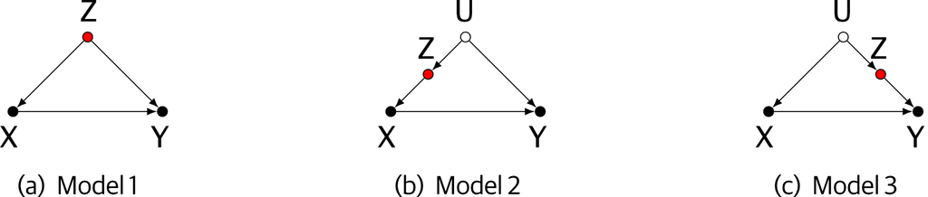

There is always a shared common cause between X and Y, and estimating the effect of X on Y requires blocking this non-causal path. The variable Z can be used as a covariate in all cases, even in the presence of the unobserved confound U.

Let’s check this by simulating the DAG in model 2:

```r
N = 100
U = rnorm(N)
b_zu = 0.5
Z = rnorm(N, b_zu * U)
b_xz = 0.8
X = rnorm(N, b_xz * Z)
b_yu = 1
b_yx = 1
Y = rnorm(N, b_yu * U + b_yx * X)

lm(Y ~ X) |> coef() # Biased by non-causal path, effect of X is overestimated
lm(Y ~ X + Z) |> coef() # Unbiased, effect of X is correct and equal to b_yx
```

The same logic applies if the confound is mediated by another variable M:

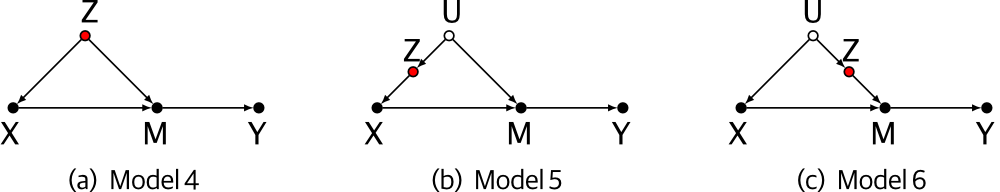

Z should be added as a covariate in all of these cases.

**Question**: If we are interested in the effect of X on Y, could M also be added to the model? Explain.

**Exercise**: Choose one of these DAGs and run a simulation, explore the effect of adding Z or M as covariates.

## Pretty good controls

Adding Z as a covariate increases the precision of the estimate of the effect of X on Y.

Again, let’s check using simulations:

```r
set.seed(2)
library(rethinking)
N = 200
X = rnorm(N)
Z = rnorm(N)
b_yx = 1
b_yz = 2
Y = rnorm(N, b_yx * X + b_yz * Z)

yx = lm(Y ~ X) |> extract.samples()
yxz = lm(Y ~ X + Z) |> extract.samples()
dens(yxz$X, lwd = 2, col = 2, xlim = c(0.4, 1.65), xlab = "b_yx")
dens(yx$X, lwd = 2, col = 1, add =TRUE)
```

[output not shown]

This happens because adding the covariate removes part of the variation in Y that is not associated with X.

**Question**: What if Z is a cause of X, not of Y. Would adding it to the regression help in this case?

# Bad controls

Two classes of bad controls are the posttreatment or overcontrol bias, and bias amplification.

In the following DAGs, controlling on Z would lead to a understimate of the effect of X on Y.

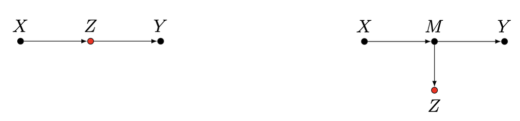

In the following case, controlling on Z would lead to an increase in the bias caused by the unobserved variable U.

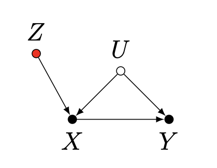

**Exercise**: Simulate the bias amplification example and check the effect of including the Z variable in the model.

## AIC and significance won’t help you

To explore the effect of a bad control variable, let’s simulate a collider:

```r
# DAG : X -> Z <- Y
N = 200
X = rnorm(N)
Y = rnorm(N)
Z = rnorm(N, Y + X)

m1 = lm(Y~X)   # Correct model
m2 = lm(Y~X+Z) # Model including the collider
```

First, let’s look at the significance of the variables in both models:

```r
summary(m1)
summary(m2)
```

[output not shown]

Many researchers would interpret the significant results in model 2 as evidence that both X and Z affect Y, don’t make this mistake! Statistical models are blind to causes, they only capture associations.

How about AIC? Would model comparison identify the correct model?

```r
library(bbmle)
AICctab(m1, m2, mnames = c("Correct", "Biased"),
        base=TRUE, weights = TRUE, nobs = N)
```

[output not shown]

**The only way to identify the possible bias is having a clear scientific model.**

# Practice DAGs

For each of the following DAGs form the rethinking book, write down the correct models for estimating the total causal influence of X on Y:

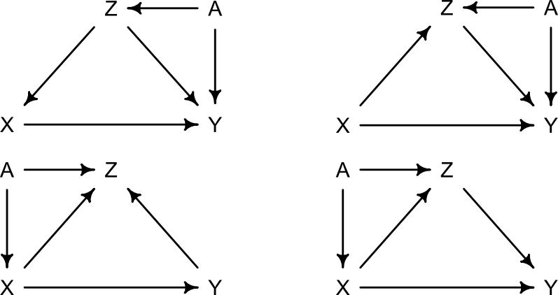

You can check your answers using the dagitty package or the [online interface](http://www.dagitty.net/dags.html)[^1]. Here is an example:

```r
library(dagitty)
dag1 = dagitty('dag { X -> Y Z -> X Z -> Y A -> Z A -> Y}')

# Plotting the dag, we can use coordinates to place the nodes in the desired position
coordinates( dag1 ) <-
    list( x=c(X = 0, Y = 2, Z = 1, A = 2),
          y=c(X = 0, Y = 0, Z = -1, A = -1) )
plot(dag1)

# get all paths
paths(dag1, from = "X", to = "Y")

# get the correct adjustment set
adjustmentSets(dag1, exposure = "X", outcome = "Y")
```

[output not shown]

[^1]: For begginers, we reccomend to start playing with this interface, and then check the results with the `dagitty` package